# RGEs of PBH

**Tae Geun Kim**

## 1. For $\lambda$

### 1) Import Data

- Using Mathematica, generate table (name="lHTab.csv")
- If you want to see a full code, then click below.

```python
from IPython.display import HTML

HTML('''<script>
code_show=true;
function code_toggle() {
 if (code_show){
 $('div.input').hide();
 } else {
 $('div.input').show();
 }
 code_show = !code_show
}
$( document ).ready(code_toggle);
</script>
<form action="javascript:code_toggle()"><input type="submit" value="Click here to toggle on/off the raw code."></form>''')
```

```python
# Text to List
import ast

# Import & Edit data automatically.
temp = open('/home/rakhan/PBH_data/lHTab.csv')
Data = [line.strip().strip('"') for line in temp]
for i, mass_group in enumerate(Data):
    Data[i] = ast.literal_eval(mass_group)

# Extract t, $\lambda$
for i in range(165,176):
    locals()['t_'+str(i)] = []
    locals()['lambda_'+str(i)] = []
for i, mass_group in enumerate(Data):
    for values in mass_group:
        locals()['t_'+str(i+165)].append(values[0])
        locals()['lambda_'+str(i+165)].append(values[2])
```

### 2) Plot $\lambda$

#### - Simple Plot

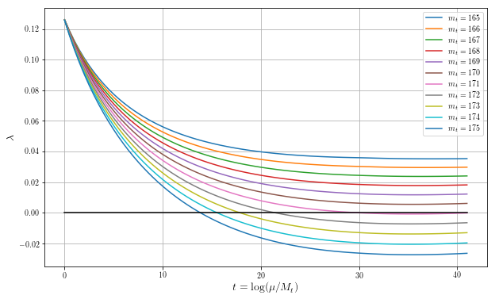

```python
# Matplotlib
import matplotlib.pyplot as plt

# Use latex
plt.rc('text', usetex=True)
plt.rc('font', family='serif')
null=[0 for i in t_165]
plt.figure(figsize=(10,6))
for i in range(165, 176):
    plt.plot(locals()['t_'+str(i)],locals()['lambda_'+str(i)],label=r"$m_t="+str(i)+"$")
plt.plot(t_165, null, color='black')
plt.legend()
plt.xlabel(r'$t=\log(\mu/M_t)$', fontsize=14)
plt.ylabel(r'$\lambda$', fontsize=14)
plt.grid()
plt.show()
```

#### - Beautiful Plot (Optional)

```python
#import plotly.plotly as py
#import plotly.graph_objs as go
#from plotly.tools import FigureFactory as FF
```

```python
#for i in range(165,176):
#    locals()['trace'+str(i-165)] = go.Scatter(
#        x = t_165,
#        y = locals()['lambda_'+str(i)],
#        mode = 'lines',
#        name = '$M_t='+str(i)+'$'
#    )
#data = [trace0, trace1, trace2, trace3, trace4, trace5, trace6, trace7, trace8, trace9, trace10]
#layout = go.Layout(
#    xaxis=dict(
#        title='$\\log(\\mu/M_t)$',
#    ),
#    yaxis=dict(
#        title='$\\lambda$',
#    )
#)
#fig = go.Figure(data=data, layout=layout)
#py.iplot(fig, filename='PBH_lambda')
```

#### - Conclusion

- Thus, we can find if $M_t > 171GeV$, then $\lambda$ should be negative
- Then let's check $M_t \simeq 171GeV$.

### 3) More Specific ($170 \sim 171GeV$)

#### - Import Data from Mathematica

```python
# Import & Edit data automatically.
temp2 = open('/home/rakhan/PBH_data/lHTabl.csv')
Data2 = [line.strip().strip('"') for line in temp2]
for i, mass_group in enumerate(Data2):
    Data2[i] = ast.literal_eval(mass_group)

# Extract t, $\lambda$
for i in range(101):
    locals()['t2_'+str(i)] = []
    locals()['lambda2_'+str(i)] = []
for i, mass_group in enumerate(Data2):
    for values in mass_group:
        locals()['t2_'+str(i)].append(values[0])
        locals()['lambda2_'+str(i)].append(values[2])
```

#### - Plot

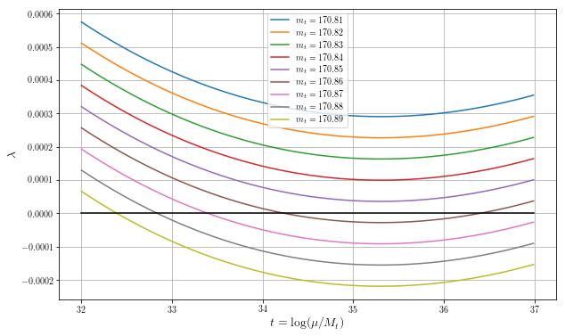

```python
# See 170.81 - 170.89
NULL = [0 for i in range(0,4001)]
plt.figure(figsize=(10,6))
for i in range(101):
    if 80<i<90:
        plt.plot(locals()['t2_'+str(i)][3200:3700],locals()['lambda2_'+str(i)][3200:3700],label=r"$m_t=170."+str(i)+"$")
plt.plot(t2_0[3200:3700],NULL[3200:3700],color='black')
plt.xlabel(r'$t=\log(\mu/M_t)$', fontsize=14)
plt.ylabel(r'$\lambda$', fontsize=14)
plt.legend()
plt.grid()
plt.show()
```

#### - Conclusion

- We can find $M_t \in (170.85, 170.86)$

  > Thus, let's find $33\leq t\leq 37,\,170.85\leq M_t \leq 170.86$

### 4) More Precise ($33\leq t\leq 37,\,170.85\leq M_t \leq 170.86$)

#### - Import Data from Mathematica

```python
# Import & Edit data automatically.
temp3 = open('/home/rakhan/PBH_data/LHTab.csv')
Data3 = [line.strip().strip('"') for line in temp3]
for i, mass_group in enumerate(Data3):
    Data3[i] = ast.literal_eval(mass_group)

# Extract t, $\lambda$
for i in range(40001):
    locals()['t3_'+str(i)] = []
    locals()['lambda3_'+str(i)] = []
for i, mass_group in enumerate(Data3):
    for values in mass_group:
        locals()['t3_'+str(i)].append(values[0])
        locals()['lambda3_'+str(i)].append(values[2])
```

#### - Find minimum $|\lambda|<10^{-6}$

```python
keys = []
for i in range(101):
    if abs(min(locals()['lambda3_'+str(i)]))<0.000001:
        if i not in keys:
            keys.append(i)
print(keys)
```

```
[55, 56, 57]
```

- The reult saids $M_t = 170.8555, 170.8556, 170.8557$

#### - Plot

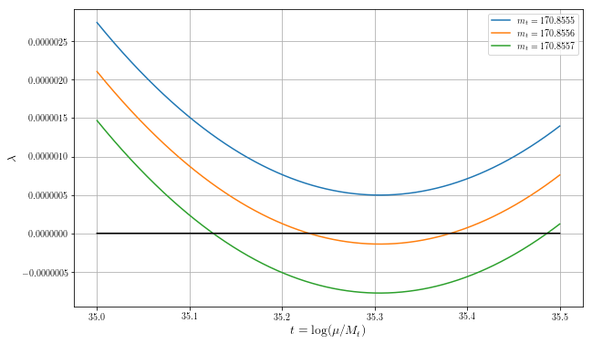

```python
NULL2 = [0 for i in t3_0]
plt.figure(figsize=(10,6))
for i in keys:
    plt.plot(locals()['t3_'+str(i)][20000:25000],locals()['lambda3_'+str(i)][20000:25000],label=r"$m_t=170.85"+str(i)+"$")
plt.plot(t3_0[20000:25000],NULL2[20000:25000],color='black')
plt.xlabel(r'$t=\log(\mu/M_t)$', fontsize=14)
plt.ylabel(r'$\lambda$', fontsize=14)
plt.legend()
plt.grid()
plt.show()
```

```python
from math import log10, exp
```

```python
# The minimum Value
print('Minimum of 170.8555: ', min(lambda3_55))
print('Minimum of 170.8556: ',min(lambda3_56))

# Where is the minimum?
for i in range(len(lambda3_55)-1):
    if lambda3_55[i] < lambda3_55[i+1]:
        print('170.8555: t=' ,33+0.0001*i,' log10(t)=', log10(exp(33+0.0001*i)))
        break
for i in range(len(lambda3_56)-1):
    if lambda3_56[i] < lambda3_56[i+1]:
        print('170.8556: t=' ,33+0.0001*i,' log10(t)=',log10(exp(33+0.0001*i)))
        break
```

```
Minimum of 170.8555:  4.977301592e-07
Minimum of 170.8556:  -1.404258781e-07
170.8555: t= 35.3055  log10(t)= 15.332983830835259
170.8556: t= 35.3055  log10(t)= 15.332983830835259
```

```python
lambda3_55[23055]
```

```
4.977301592e-07
```

#### - Conclusion

- $170.8555 \leq M_t \leq 170.8556$
- $M_t = 170.8555 \rightarrow t=35.3055:\, \lambda=4.977301592\times10^{-7}$
- $M_t = 170.8556 \rightarrow t=35.3055:\, \lambda=-1.404258781\times10^{-7}$

## 2. For $\displaystyle \frac{d\lambda}{d\ln\mu}$

### 1) Overview

#### - Import Data from Mathematica

```python
# Import & Edit data automatically.
tempb = open('/home/rakhan/PBH_data/lHdTab.csv')
Datab = [line.strip().strip('"') for line in tempb]
for i, mass_group in enumerate(Datab):
    Datab[i] = ast.literal_eval(mass_group)

# Extract t, $\lambda$
for i in range(len(Datab)):
    locals()['tb_'+str(i)] = []
    locals()['lambdab_'+str(i)] = []
for i, mass_group in enumerate(Datab):
    for values in mass_group:
        locals()['tb_'+str(i)].append(values[0])
        locals()['lambdab_'+str(i)].append(values[2])
```

#### - Plot

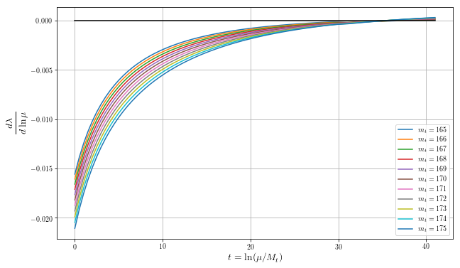

```python
null=[0 for i in tb_0]
plt.figure(figsize=(10,6))
for i in range(len(Datab)):
    plt.plot(locals()['tb_'+str(i)],locals()['lambdab_'+str(i)],label=r"$m_t="+str(i+165)+"$")
plt.plot(tb_0, null, color='black')
plt.legend()
plt.xlabel(r'$t=\ln(\mu/M_t)$', fontsize=14)
plt.ylabel(r'$\displaystyle \frac{d\lambda}{d\ln\mu}$', fontsize=14)
plt.grid()
plt.show()
```